# Data

Data of the project are Zip.csv and FamilyHome_Sales.csv (See introdution for more information)

## Data Analysis

The data analysis part contains two datasets using descriptive analysis, data visualization and more inferentialv statistical analyses

### Descriptive Analysis + Data visualization

Since datasets are already loaded. The first step is to use the summary function to conclude the number of males and females in the zipcode file.

Five-factor summary of the count of males

```
##    Min. 1st Qu.  Median    Mean 3rd Qu.    Max.
##   0.000   0.000   0.000   7.364   4.000 157.000
```

Five-factor summary of the count of females

```
##    Min. 1st Qu.  Median    Mean 3rd Qu.    Max.
##     0.0     0.0     0.0    10.3     6.0   194.0
```

Five-factor summary of the count of Asian, Non Hispanic

```
##    Min. 1st Qu.  Median    Mean 3rd Qu.    Max.
##  0.0000  0.0000  0.0000  0.5254  0.0000 28.0000
```

Five-factor summary of the count of Black, Non Hispanic

```
##    Min. 1st Qu.  Median    Mean 3rd Qu.    Max.
##   0.000   0.000   0.000   2.233   0.000  60.000
```

Five-factor summary of Averagae Housing Sale Price in NYC (2009)

`## Min. 1st Qu. Median Mean 3rd Qu. Max. ## 390000 1114000 3800000 4635000 6662000 19500000`

Five-factor summary of Lowest Housing Sale Price in NYC (2009)

`## Min. 1st Qu. Median Mean 3rd Qu. Max. ## 320000 788400 2350000 3177000 3800000 19500000`

Five-factor summary of Highest Housing Sale Price in NYC (2009)

`## Min. 1st Qu. Median Mean 3rd Qu. Max. ## 390000 1700000 4700000 6723000 9750000 25000000`

Use ggplot to the distribution of totoal number of properties vs. number of sales in NYC (2009)

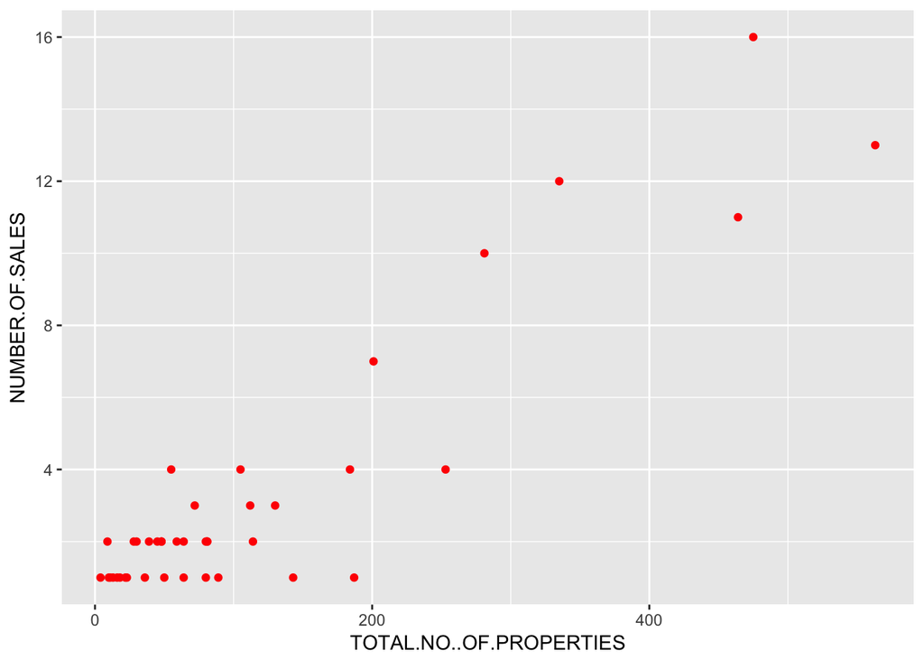

Use ggplot to the distribution of lowest sale prices vs. type of home (2009)

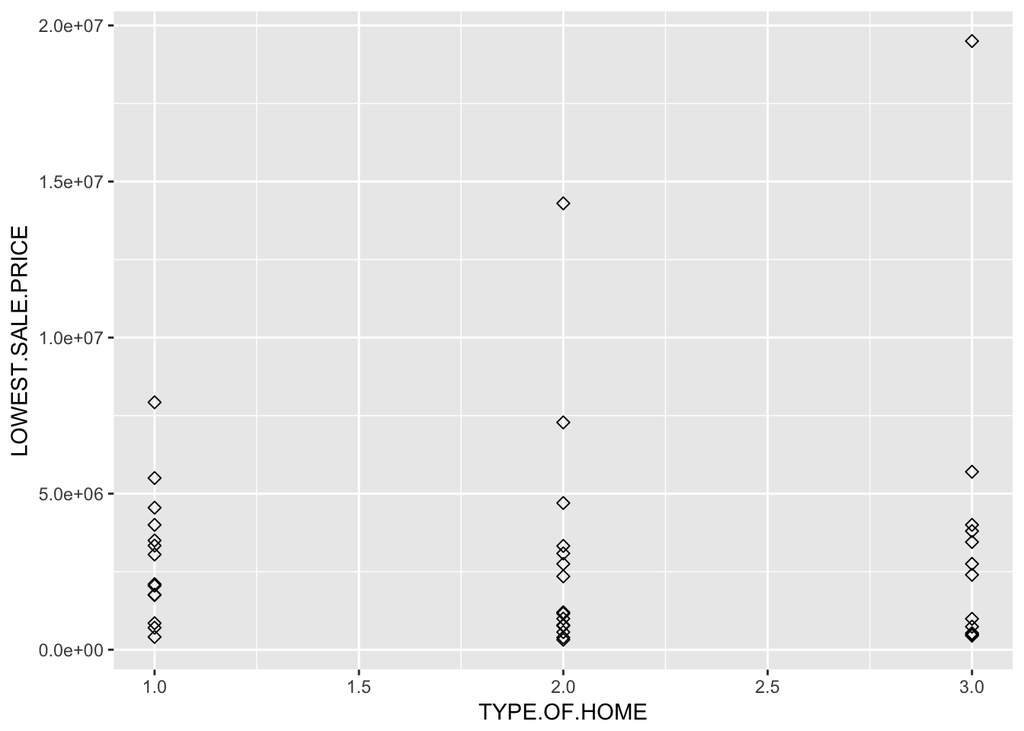

Use ggplot to the distribution of median sale prices vs. type of home (2009)

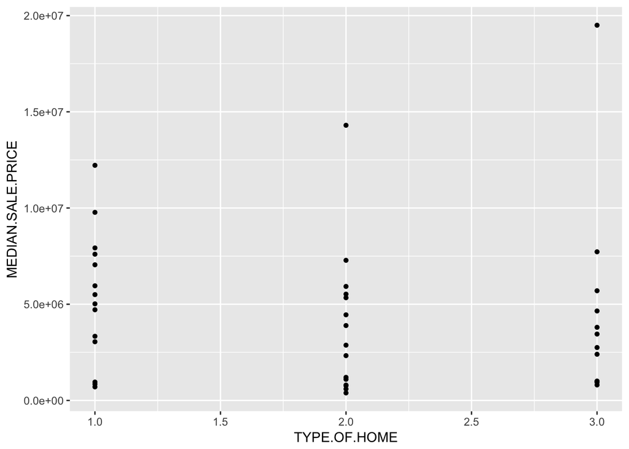

Use ggplot to the distribution of highest sale prices vs. type of home (2009)

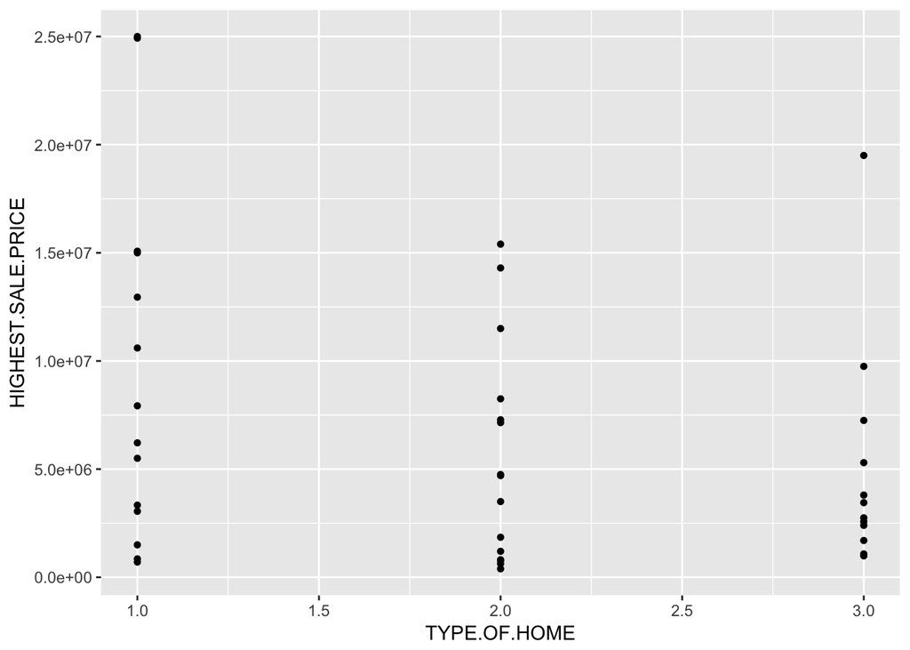

Use ggplot to the distribution of average sale prices vs. type of home (2009)

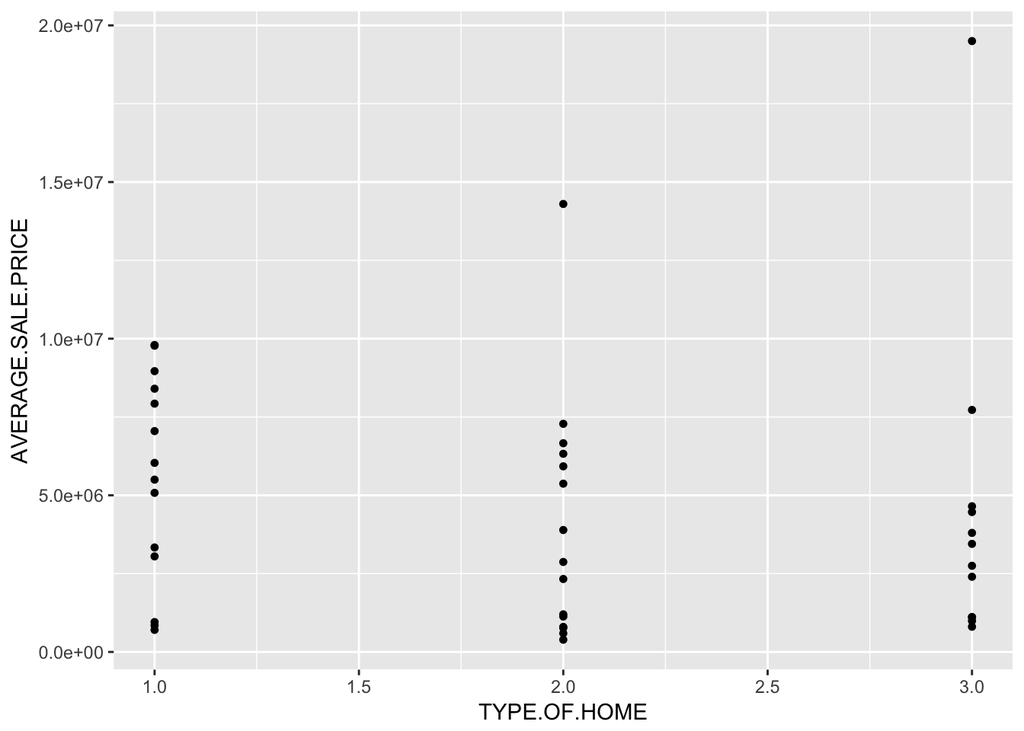

Display the histogram of the percent of Asian

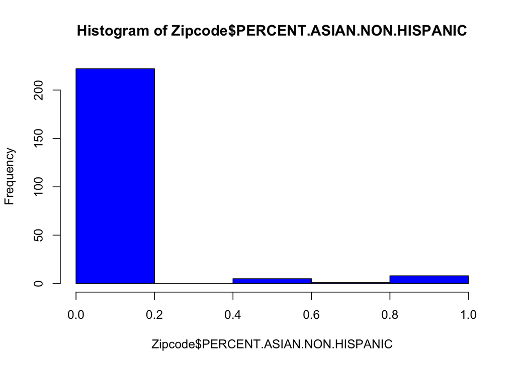

Display the histogram of the percent of Black

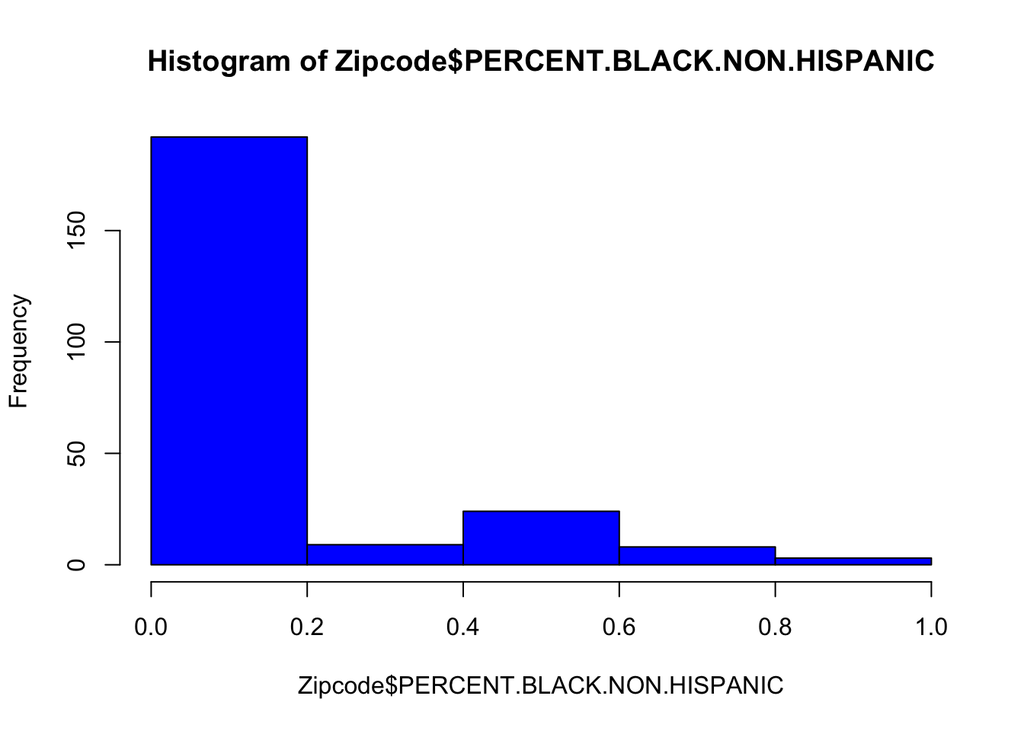

Display the histogram of the percent of US Citizens

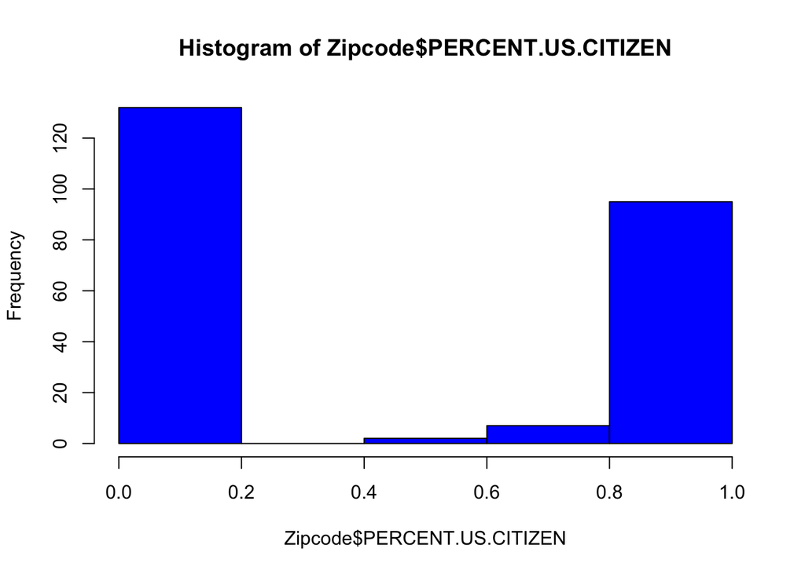

————————————————————————————————————-

## Inferential Statistical Analyses

### Correlation, Regression, t-test, Wilcox Test, ANOVA, Cumulative Distribution

Find the correlation between the number of female and male

```
## [1] 0.6782909
```

Conduct a regression analysis of the number of citizen and the number of males

```
##
## Call:
## lm(formula = Zipcode$COUNT.US.CITIZEN ~ Zipcode$COUNT.MALE)
##
## Coefficients:
##        (Intercept)  Zipcode$COUNT.MALE
##              2.567               1.983
```

Multiple Regression of percent of citizen total, percent of feamle, percent of pacific islander and percent of public assistance total

```
##
## Call:
## lm(formula = Zipcode$PERCENT.CITIZEN.STATUS.TOTAL ~ Zipcode$PERCENT.FEMALE +
##     Zipcode$PERCENT.PACIFIC.ISLANDER + Zipcode$PERCENT.PUBLIC.ASSISTANCE.TOTAL)
##
## Coefficients:
##                             (Intercept)
##                              -3.501e-14
##                  Zipcode$PERCENT.FEMALE
##                              -2.565e-03
##        Zipcode$PERCENT.PACIFIC.ISLANDER
##                               5.340e-01
## Zipcode$PERCENT.PUBLIC.ASSISTANCE.TOTAL
##                               9.999e-01
```

Conduct a two sample t-test of the number of American Indian and Asian Non Hispanic

```
##
##  Welch Two Sample t-test
##
## data:  Zipcode$COUNT.AMERICAN.INDIAN and Zipcode$COUNT.ASIAN.NON.HISPANIC
## t = -3.478, df = 237.8, p-value = 0.0006007
## alternative hypothesis: true difference in means is not equal to 0
## 95 percent confidence interval:
##  -0.7898485 -0.2186261
## sample estimates:
##  mean of x  mean of y
## 0.02118644 0.52542373
```

Conduct a two sample t-test of the number of black non hispanic and white non hispanic

```
##
##  Welch Two Sample t-test
##
## data:  Zipcode$COUNT.BLACK.NON.HISPANIC and Zipcode$COUNT.WHITE.NON.HISPANIC
## t = -3.7696, df = 250.56, p-value = 0.000204
## alternative hypothesis: true difference in means is not equal to 0
## 95 percent confidence interval:
##  -15.160129  -4.755125
## sample estimates:
## mean of x mean of y
##  2.233051 12.190678
```

Conduct a Rank sum test of the number of males and females

```
##
##  Wilcoxon rank sum test with continuity correction
##
## data:  Zipcode$COUNT.MALE and Zipcode$COUNT.FEMALE
## W = 27150, p-value = 0.5961
## alternative hypothesis: true location shift is not equal to 0
```

Conduct a rank sum test of the number of people who receives the public assistance and those people who do not receive

```
##
##  Wilcoxon rank sum test with continuity correction
##
## data:  Zipcode$COUNT.RECEIVES.PUBLIC.ASSISTANCE and Zipcode$COUNT.NRECEIVES.PUBLIC.ASSISTANCE
## W = 25296, p-value = 0.05115
## alternative hypothesis: true location shift is not equal to 0
```

Find the difference between the number of people who receives the public assistance and those people who do not receive

```
##
##  Wilcoxon signed rank test
##
## data:  DiffPubAssist
## V = 91, p-value = 0.0002441
## alternative hypothesis: true location is not equal to 0
```

Conduct a ANOVA test using the percent of Asians and Americans

```
## Call:
##    aov(formula = PERCENT.ASIAN.NON.HISPANIC ~ PERCENT.AMERICAN.INDIAN,
##     data = Zipcode)
##
## Terms:
##                 PERCENT.AMERICAN.INDIAN Residuals
## Sum of Squares                 0.004045  9.410875
## Deg. of Freedom                       1       234
##
## Residual standard error: 0.2005428
## Estimated effects may be unbalanced
```

Cumulative distribution function of Count Participants

[output not shown]

[output cut: 19 more lines]

Conduct a rank sum testof houses with lowest sales price and highest sales price

```
##
##  Wilcoxon rank sum test with continuity correction
##
## data:  FHS$LOWEST.SALE.PRICE and FHS$HIGHEST.SALE.PRICE
## W = 529.5, p-value = 0.003978
## alternative hypothesis: true location shift is not equal to 0
```

Conduct a rank sum test of houses with lowest sales price and average sales price

```
##
##  Wilcoxon rank sum test with continuity correction
##
## data:  FHS$AVERAGE.SALE.PRICE and FHS$LOWEST.SALE.PRICE
## W = 1079.5, p-value = 0.02696
## alternative hypothesis: true location shift is not equal to 0
```

Conduct a rank sum test of houses with highest sales price and average sales price

```
##
##  Wilcoxon rank sum test with continuity correction
##
## data:  FHS$AVERAGE.SALE.PRICE and FHS$HIGHEST.SALE.PRICE
## W = 719, p-value = 0.2618
## alternative hypothesis: true location shift is not equal to 0
```

Conduct a two sample t-test of houses with highest sales price and average sales price

```
##
##  Welch Two Sample t-test
##
## data:  FHS$AVERAGE.SALE.PRICE and FHS$HIGHEST.SALE.PRICE
## t = -1.7441, df = 66.826, p-value = 0.08574
## alternative hypothesis: true difference in means is not equal to 0
## 95 percent confidence interval:
##  -4478764.0   301758.2
## sample estimates:
## mean of x mean of y
##   4634713   6723216
```

Conduct a two sample t-test of houses with lowest sales price and average sales price

```
##
##  Welch Two Sample t-test
##
## data:  FHS$AVERAGE.SALE.PRICE and FHS$LOWEST.SALE.PRICE
## t = 1.6985, df = 79.461, p-value = 0.09333
## alternative hypothesis: true difference in means is not equal to 0
## 95 percent confidence interval:
##  -250430.1 3165877.5
## sample estimates:
## mean of x mean of y
##   4634713   3176989
```